# STA 101 - HW 2

Mingyi Xue

April 18, 2018

### Load databases into current workingspace:

```
##   Location PovPct Brth15to17
## 1  Alabama   20.1       31.5
## 2   Alaska    7.1       18.9
## 3  Arizona   16.1       35.0
```

```
##   InfctRsk MedSchool Stay
## 1      4.1        No 7.13
## 2      1.6        No 8.82
## 3      2.7        No 8.34
```

```
##   Age Temp Length
## 1  14   25    620
## 2  28   25   1315
## 3  41   25   2120
```

### Load package `ggplot2`:

```r
library(ggplot2)
```

### Problem 1

**(a)**

```
##
##  Shapiro-Wilk normality test
##
## data:  the.e_i
## W = 0.97436, p-value = 0.3324
```

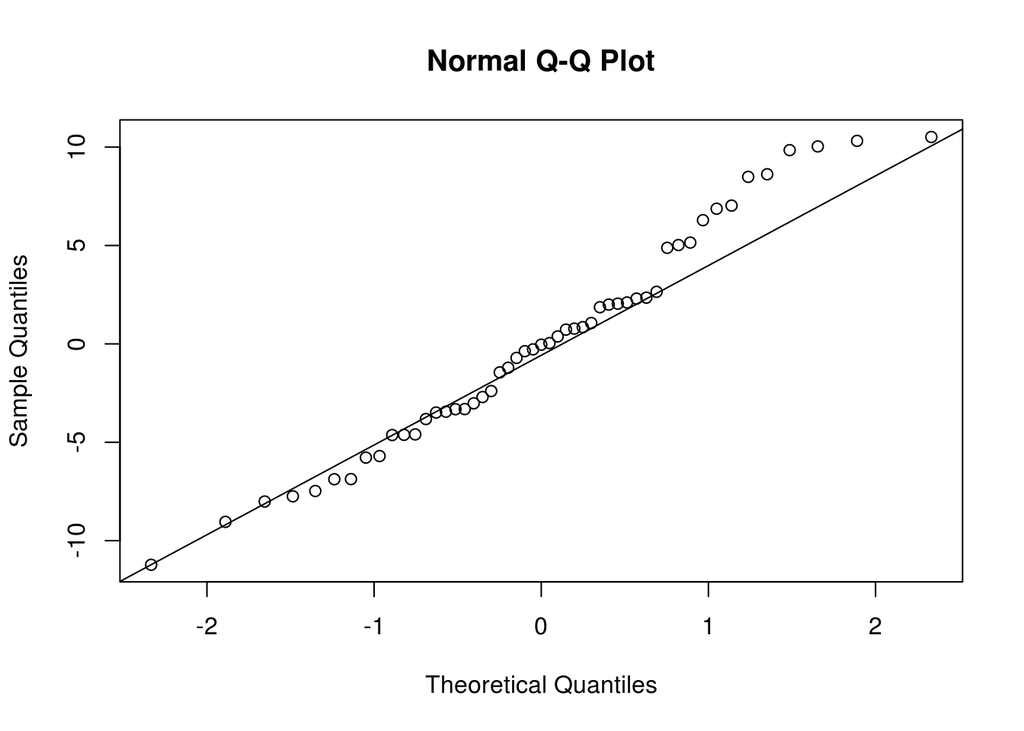

This plot has most of the points very close to the line, with several possible outliers.  
$H_{0}$: The errors are normally distributed.  
$H_{A}$: The errors are not normally distributed.  
The p-value of $e_{i}$ is 0.3324 and it is relatively large, so we fail to reject $H_{0}$. As a result, the errors are approximately normal.

**(b)**

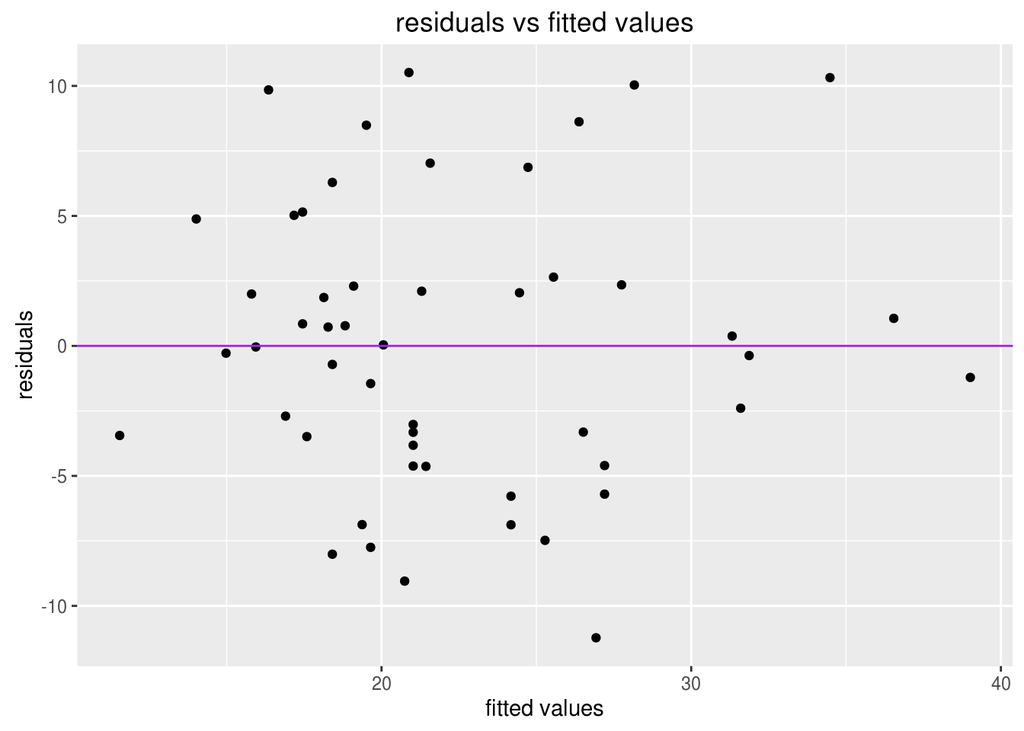

```
##
##  Fligner-Killeen test of homogeneity of variances
##
## data:  the.model$residuals and poverty$Group
## Fligner-Killeen:med chi-squared = 1.1001, df = 1, p-value = 0.2942
```

$H_{0}$: $\sigma^{2}_{lower}=\sigma^{2}_{upper}$.  
$H_{A}$: $\sigma^{2}_{lower}\neq \sigma^{2}_{upper}$.  
The p-value of variance of $e_{i}s$ is 0.2942 and it is relatively large, so we fail to reject $H_{0}$. As a result, $\sigma^{2}_{lower}=\sigma^{2}_{upper}$ and the error variance is constant.

**(c)**

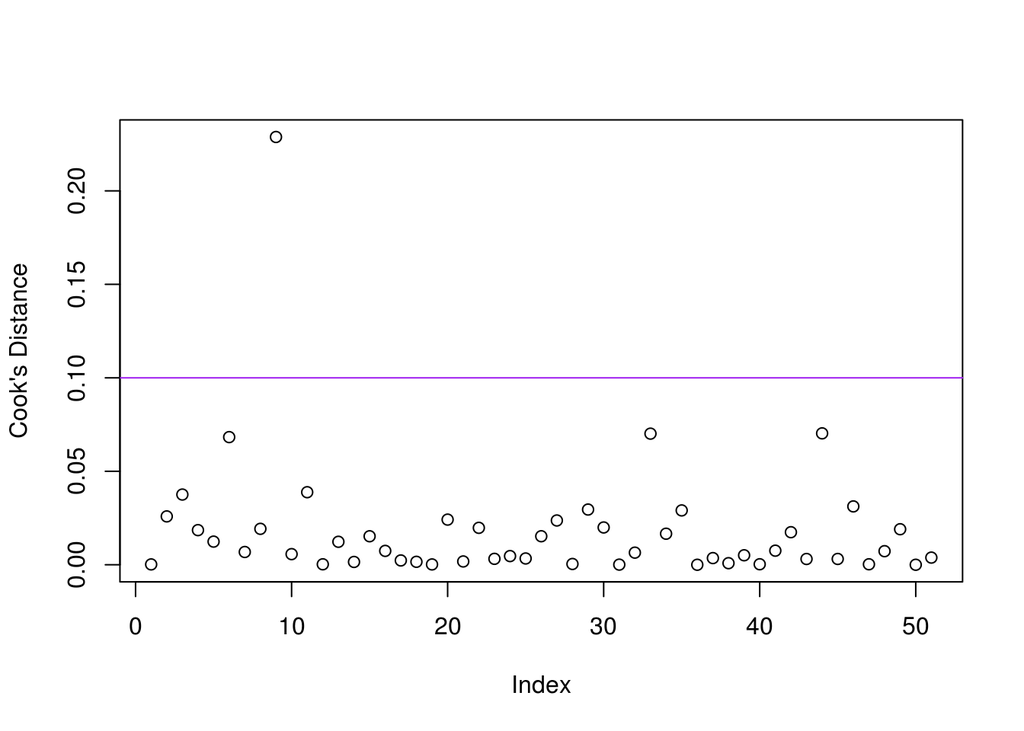

```
## integer(0)
```

I used cooks distance to find outliers, and outliers are as follows,

```
##               Location PovPct Brth15to17 Group
## 9 District_of_Columbia     22       44.8 Lower
```

**(d)**

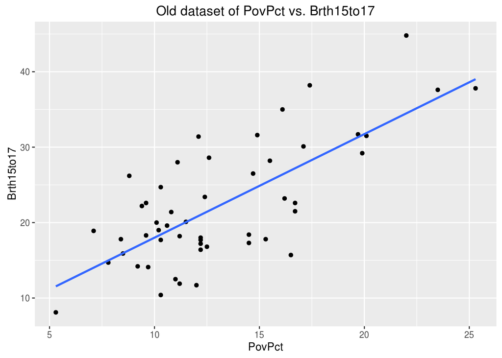

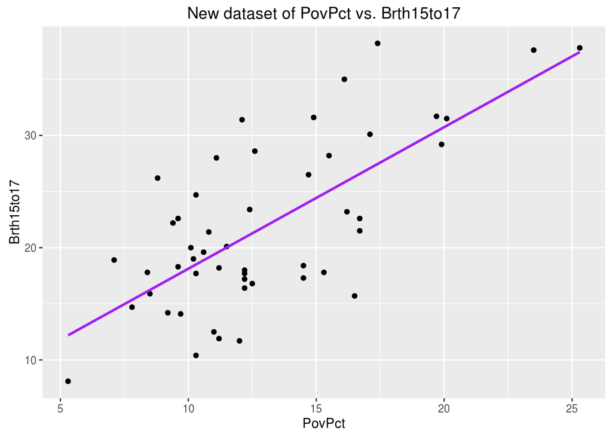

The slope of old model is 1.3733, and the slope of new model is 1.2613.  
The absolute difference is 0.112. The difference comes from excluding some extremely large outliers.

### Problem 2

**(a)**

```
##                5 %   95 %
## (Intercept) 1.2700 9.7521
## PovPct      0.9487 1.5738
```

The confidence interval for $\beta_{0}$ is 1.27, 9.7521.  
The confidence interval for $\beta_{1}$ is 0.9487, 1.5738.

**(b)**

The confidence interval for $\beta_{1}$ is 0.9487, 1.5738.  
It means we are $90\%$ confident that when the percent of the states population living in poverty increases by 1, the birth rate per 1000 females 15 to 17 years old will increase between $0.9487$ and $1.5738$ on average, holding the other variables constant.

**(c)**

Yes, because the confidence interval of PovPct does not contain 0.

**(d)**

```
##             Estimate Std. Error t value Pr(>|t|)
## (Intercept)   5.5110     2.5286  2.1795   0.0342
## PovPct        1.2613     0.1863  6.7685   0.0000
```

test statistic: $t_{s}=\frac{\hat{\beta_{1}}-0}{SE\{\hat{\beta_{1}}\}}$  
degree of freedom: 48  
$H_{0}$:$\beta_{1}=0$.  
$H_{A}$:$\beta_{1}\neq 0$.  
p-value is 0 and is small enough for us to reject $H_{0}$. As a result, $\beta_{1}\neq0$,which shows a significant linear relationship between $X_{1}$ and $Y$.

**(e)**

p-value in (d) is 0. It means if $H_{0}$ was true: $\beta_{1}=0$ and there is no linear relationship between $PovPct$ and $Brth15to17$, we will observe our data or more extreme with the probability of 0.

### Problem 3

**(a)**

```
##
##  Shapiro-Wilk normality test
##
## data:  the.e_i
## W = 0.97985, p-value = 0.086
```

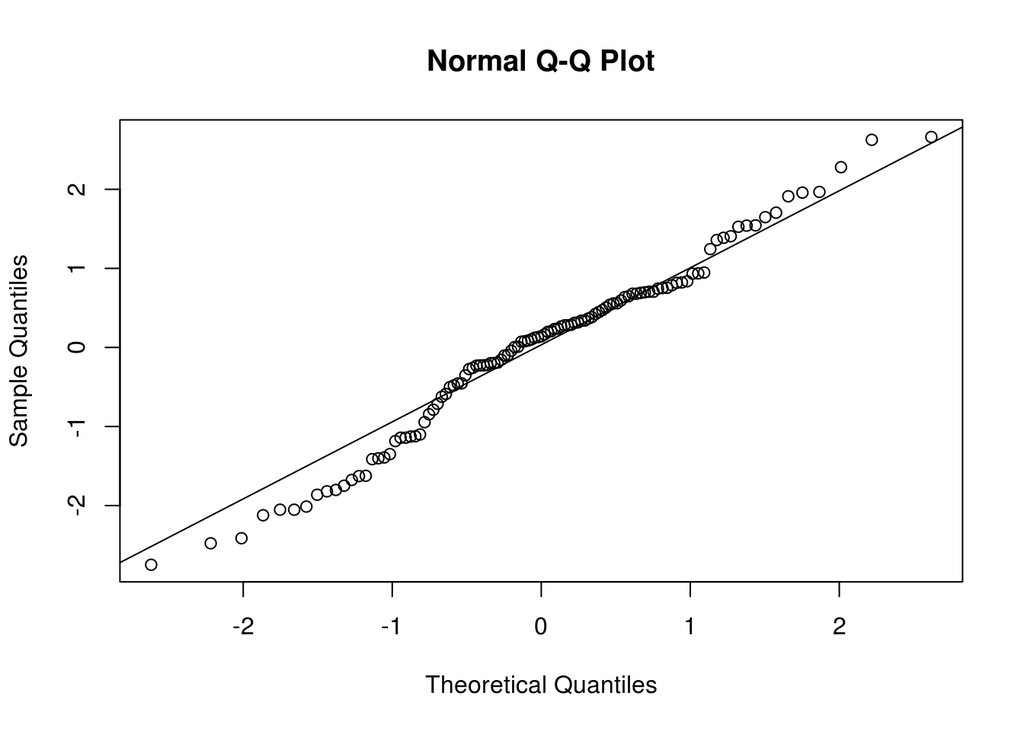

**(b)**

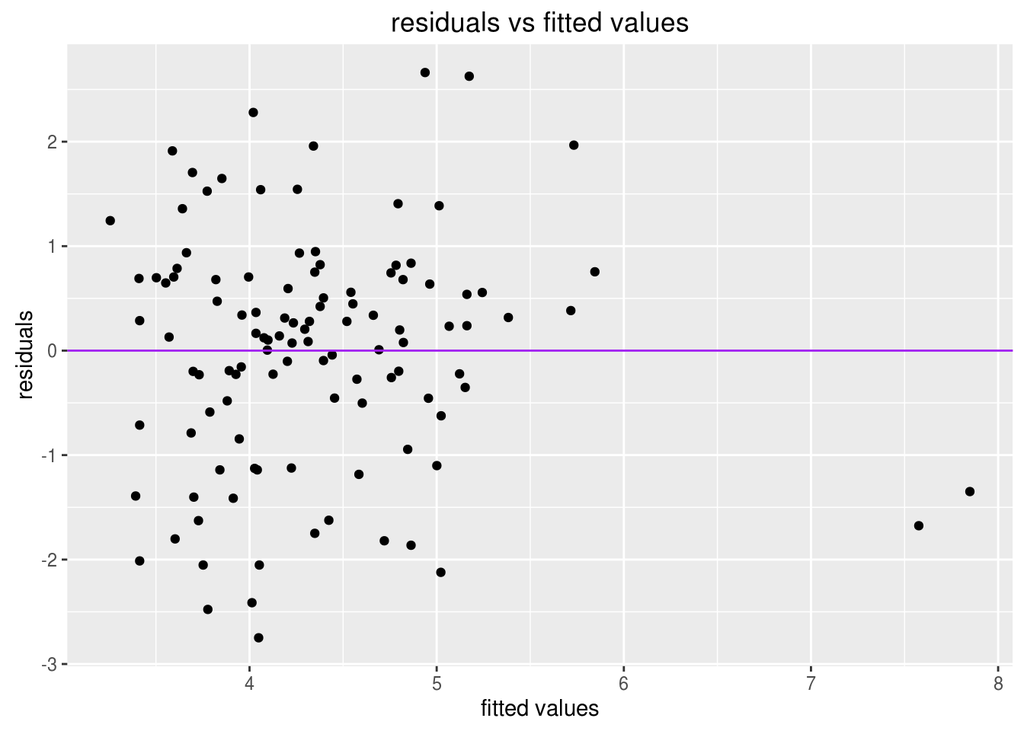

```
##
##  Fligner-Killeen test of homogeneity of variances
##
## data:  the.model$residuals and hospital$Group
## Fligner-Killeen:med chi-squared = 3.3832, df = 1, p-value =
## 0.06587
```

**(c)**

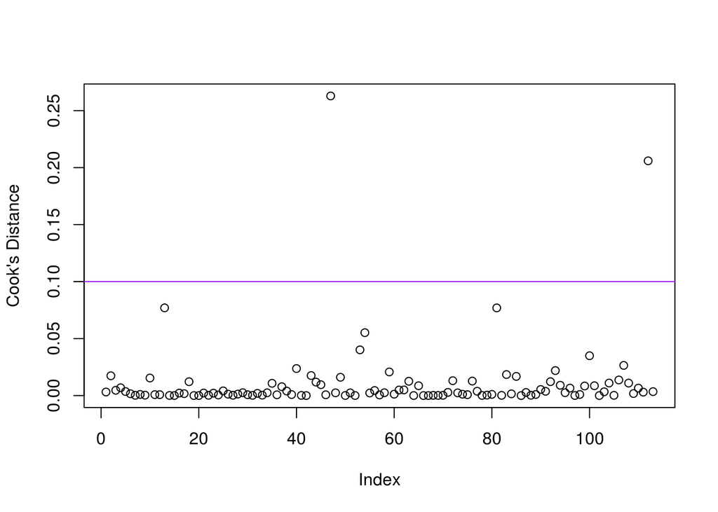

```
## integer(0)
```

I used cook’s distance to find outliers, and outliers are as follows,

```
##     InfctRsk MedSchool  Stay Group
## 47       6.5        No 19.56 Lower
## 112      5.9       Yes 17.94 Lower
```

**(d)**

The slope of two models are as follows,

```
##           MedSchool_Yes   Stay
## Old model        0.3056 0.3572
## new Model        0.2453 0.4776
```

The absolute difference is 0.1204.

### Problem 4

**(a)**

```
##                  5 %   95 %
## (Intercept)  -1.4273 0.9414
## MedSchoolYes -0.2799 0.7705
## Stay          0.3519 0.6032
```

The confidence interval for $\beta_{0}$ is -1.4273, 0.9414.  
The confidence interval for $\beta_{1}$ is -0.2799, 0.7705.  
The confidence interval for $\beta_{2}$ is 0.3519, 0.6032.

**(b)**

The confidence interval for $\beta_{2}$ is 0.3519, 0.6032.  
It means we are $90\%$ confident that when the average length of stay for patients increases by 1 day, the estimated percentage of patients who get a secondary infection during their hospital stay will increase between $0.3519$ and 0.6032 days on average.

**(c)**

Yes, because the confidence interval of $X_{2}$ or $Stay$ does not contain 0.

**(d)**

```
##              Estimate Std. Error t value Pr(>|t|)
## (Intercept)   -0.2430     0.7139 -0.3404   0.7342
## MedSchoolYes   0.2453     0.3165  0.7749   0.4401
## Stay           0.4776     0.0757  6.3057   0.0000
```

test statistic: $t_{s}=\frac{\hat{\beta_{2}}-0}{SE\{\hat{\beta_{2}}\}}$  
degree of freedom: 108  
$H_{0}$:$\beta_{2}=0$.  
$H_{A}$:$\beta_{2}\neq 0$.  
p-value is 0 and is small enough for us to reject $H_{0}$. As a result, $\beta_{2}\neq0$,which shows a significant linear relationship between $X_{2}$ and $Y$.

**(e)**

p-value in (d) is 0. It means if $H_{0}$ was true: $\beta_{2}=0$ and there is no linear relationship between $Stay$ and $InfctRsk$, we will observe our data or more extreme with the probability of 0.

### Problem 5

**(a)**

The model with an interaction term is: $\hat{y}=-0.1031-1.7873X_{1}+0.4625X_{2}+0.1943X_{1}X_{2}$

**(b)**

The confidence intervals of $\beta$s are as follows:

```
##                     0.5 % 99.5 %
## (Intercept)       -2.0550 1.8488
## MedSchoolYes      -9.6264 6.0517
## Stay               0.2552 0.6698
## MedSchoolYes:Stay -0.5509 0.9395
```

```
##                     2.5 % 97.5 %
## (Intercept)       -1.5786 1.3724
## MedSchoolYes      -7.7128 4.1382
## Stay               0.3058 0.6192
## MedSchoolYes:Stay -0.3690 0.7576
```

```
##                       5 %   95 %
## (Intercept)       -1.3380 1.1318
## MedSchoolYes      -6.7469 3.1722
## Stay               0.3314 0.5937
## MedSchoolYes:Stay -0.2771 0.6658
```

**(c)**

$X_{2}$ or $Stay$ should be retained for the model because its confidence interval does not contain $0$.

**(d)**

When $X_{1}$ or $X_{Yes}$ changes by 1 unit we can expect the largiest change in $Y$, though it varies fluctuately.

### Problem 6

**(a)**

```
##
##  Shapiro-Wilk normality test
##
## data:  the.e_i
## W = 0.99395, p-value = 0.998
```

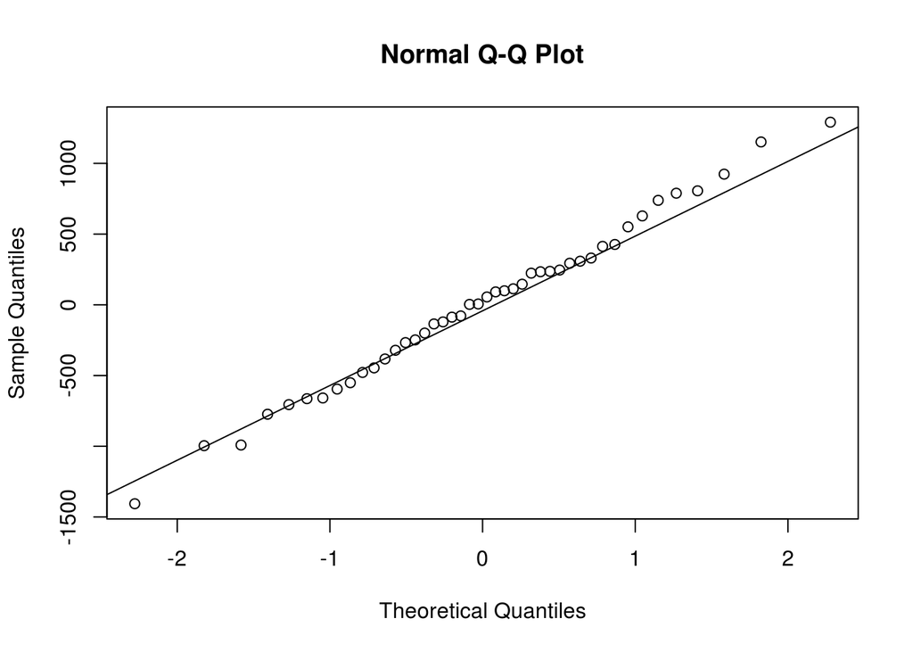

This plot has most of the points very close to the line, with several possible outliers.  
$H_{0}$: The errors are normally distributed.  
$H_{A}$: The errors are not normally distributed.  
The p-value of $e_{i}$ is 0.998. It is relatively large, so we fail to reject $H_{0}$. As a result, the errors are approximately normal.

**(b)**

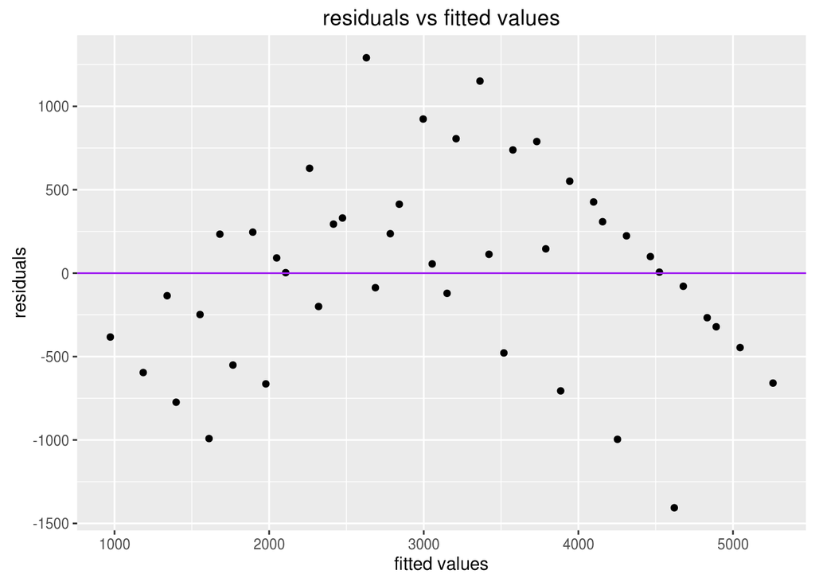

```
##
##  Fligner-Killeen test of homogeneity of variances
##
## data:  the.model$residuals and fish$Group
## Fligner-Killeen:med chi-squared = 2.5133, df = 1, p-value = 0.1129
```

$H_{0}$: $\sigma^{2}_{lower}=\sigma^{2}_{upper}$.  
$H_{A}$: $\sigma^{2}_{lower}\neq \sigma^{2}_{upper}$.  
The p-value of variance of $e_{i}s$ is 0.1129.  
Though p-value is large for us to fail to reject $H_{0}$ and come to the conclusion that the error variance is constant, the plot of residuals vs. fitted values shows variety and symmetry with values of y, and that’s where Fligner-Killeen test will fail.

**(c)**

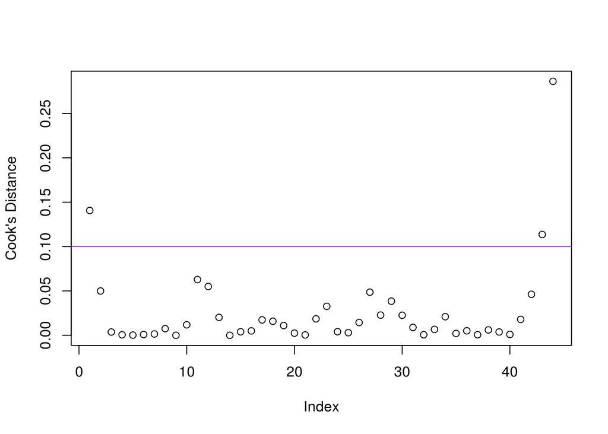

```
## integer(0)
```

I used cook’s distance to find outliers, and outliers are as follows,

```
##    Age Temp Length Group
## 1   14   25    620 Upper
## 43 139   31   3257 Lower
## 44 153   31   3214 Lower
```

**(d)**

The slope of two models are as follows,

```
##               Age      Temp
## Old model 26.2407 -106.4136
## new Model 27.7076  -78.6913
```

The absolute difference is 27.7223.

### Problem 7

**(a)**

```
##                   5 %      95 %
## (Intercept) 1240.6349 4945.0360
## Age           24.4085   31.0067
## Temp        -142.6185  -14.7641
```

The confidence interval for $\beta_{0}$ is 1240.6349, 4945.036.  
The confidence interval for $\beta_{1}$ is 24.4085, 31.0067.  
The confidence interval for $\beta_{2}$ is -142.6185, -14.7641.

**(b)**

The confidence interval for $\beta_{1}$ is 24.4085, 31.0067.  
It means we are $90\%$ confident that when the age of the fish increases by 1 day, the length of the fish will increase between $24.4085$ and $31.0067$mm on average, holding the Temperature constant.

**(c)**

Yes, because the confidence of Age does not contain 0.

**(d)**

```
##              Estimate Std. Error t value Pr(>|t|)
## (Intercept) 3092.8354  1098.6065  2.8152   0.0077
## Age           27.7076     1.9568 14.1596   0.0000
## Temp         -78.6913    37.9175 -2.0753   0.0448
```

**(e)**

p-value in (d) is 0.0448. It means if $H_{0}$ was true: $\beta_{2}=0$ and there is no linear relationship between $Temp$ and $Length$, we will observe our data or more extreme with the probability of 0.0448.

### Problem 8

**(a)**

The model with an interaction term is: $\hat{y}=3090.3624+27.7384X_{1}-78.603X_{2}-0.0011X_{1}X_{2}$

**(b)**

The confidence intervals of $\beta$s are as follows:

```
##                  0.5 %    99.5 %
## (Intercept) -3490.3739 9671.0988
## Age           -45.2435  100.7203
## Temp         -311.9446  154.7386
## Age:Temp       -2.6165    2.6143
```

```
##                  2.5 %    97.5 %
## (Intercept) -1820.0727 8000.7976
## Age           -26.7195   82.1963
## Temp         -252.7186   95.5126
## Age:Temp       -1.9527    1.9505
```

```
##                   5 %      95 %
## (Intercept) -998.2738 7178.9986
## Age          -17.6056   73.0824
## Temp        -223.5790   66.3730
## Age:Temp      -1.6261    1.6239
```

**(c)**

None of the $\beta$s should be retained for the model because the confidence interval of them all contain $0$.

**(d)**

When $X_{2}$ or $Temp$ changes by 1 unit, we can expect the largiest change in Y because it has the largiest confidence interval.

### Problem 9

**(a)**

True. $R^{2}=\frac{SSTO-SSE}{SSTO}$ and $SSTO$ maintains the same given a specific sample, while $SSE$ of the large model is always smaller than that of the small model, so the model with the most X variables has the larggest $R^{2}$.

**(b)**

True. If CI of a $\beta_{i}$ does not contain $0$, it means when $X_{i}$ increases by $1$, we are $1-\alpha\%$ confident that $Y$ will increase between the interval of CI, and that does not equal $0$, suggesting a significant linear relationship between $X_{i}$ and $Y$.

**(c)**

True. Outliers chosen by cook’s distance are those digress from the regression line fitted by other data a lot, so outliers may significantly change the slope.

**(d)**

True. $AIC=-2LL+2p$ and we maximize $LL$ to get better coefficients for the model, which means we have to minimize $AIC$.

### R Appendix

```r
setwd("/home/xmy/STA 101/Homework/HW2")
poverty<-read.csv("poverty.csv",header = TRUE)
head(poverty,n=3)
hospital<-read.csv("hospital.csv",header = TRUE)
head(hospital,n=3)
fish<-read.csv("fish.csv",header = TRUE)
head(fish,n=3)
library(ggplot2)
the.model=lm(data=poverty,Brth15to17~PovPct)
the.e_i=the.model$residuals
the.SWtest=shapiro.test(the.e_i)
the.SWtest
qqnorm(the.model$residuals)
qqline(the.model$residuals)
qplot(data=poverty,x=the.model$fitted.values,y=the.model$residuals)+ggtitle("residuals vs fitted values")+xlab("fitted values")+ylab("residuals")+geom_hline(yintercept = 0, col='purple')
Group = rep("Lower",nrow(poverty))
Group[poverty$Brth15to17 < median(poverty$Brth15to17)] = "Upper"
Group = as.factor(Group) #Changes it to a factor, which R recognizes as a grouping variable.
poverty$Group = Group
the.FKtest= fligner.test(the.model$residuals, poverty$Group)
the.FKtest
#SR=stdres(the.model)
#hist(SR,main = "Standardized residuals")
#ggplot(data=poverty,aes(x=SR))+ggtitle("histogram of standardized errors")+geom_histogram()+xlab("standardized error")
#cutoff=2
#the.outliers=which(SR<-cutoff|SR>cutoff)
#the.outliers
CD=cooks.distance(the.model)
cutoff=0.10
plot(CD,ylab="Cook's Distance")+abline(h=cutoff,col='purple')
#the.outliers=CD[CD>cutoff]
the.outliers=poverty[which(CD>cutoff),]
the.outliers
the.slope1=the.model$coefficients[2]
the.newset=poverty[-which(CD>cutoff),]
new.model=lm(data=the.newset,Brth15to17~PovPct)
the.slope2=new.model$coefficients[2]
ggplot(poverty,aes(x=PovPct,y=Brth15to17)) + geom_point(shape = 19) +geom_smooth(method='lm',se= FALSE) + ggtitle("Old dataset of PovPct vs. Brth15to17") + ylab("Brth15to17") +xlab("PovPct")
ggplot(the.newset,aes(x=PovPct,y=Brth15to17)) + geom_point(shape = 19) +geom_smooth(method='lm',se= FALSE,col='purple') + ggtitle("New dataset of PovPct vs. Brth15to17") + ylab("Brth15to17") +xlab("PovPct")
alpha = 0.10
the.CIs = confint(new.model,level = 1-alpha)
round(the.CIs,4)


the.summary=summary(new.model)
the.coef=the.summary$coefficients
round(the.coef,4)

the.model=lm(data=hospital,InfctRsk~MedSchool+Stay)
the.e_i=the.model$residuals
the.SWtest=shapiro.test(the.e_i)
the.SWtest
qqnorm(the.model$residuals)
qqline(the.model$residuals)
qplot(data=hospital,x=the.model$fitted.values,y=the.model$residuals)+ggtitle("residuals vs fitted values")+xlab("fitted values")+ylab("residuals")+geom_hline(yintercept = 0, col='purple')
Group = rep("Lower",nrow(hospital))
Group[hospital$InfctRsk < median(hospital$InfctRsk)] = "Upper"
Group = as.factor(Group) #Changes it to a factor, which R recognizes as a grouping variable.
hospital$Group = Group
the.FKtest= fligner.test(the.model$residuals, hospital$Group)
the.FKtest
CD=cooks.distance(the.model)
cutoff=0.10
plot(CD,ylab="Cook's Distance")+abline(h=cutoff,col='purple')
the.outliers=hospital[which(CD>cutoff),]
the.outliers
the.newset=hospital[-which(CD>cutoff),]
new.model=lm(data=the.newset,InfctRsk~MedSchool+Stay)
the.matrix=matrix(c(the.model$coefficients[2],the.model$coefficients[3],
                    new.model$coefficients[2],new.model$coefficients[3]),byrow=TRUE,nrow=2)
rownames(the.matrix)=c('Old model','new Model')
colnames(the.matrix)=c('MedSchool_Yes','Stay')
round(the.matrix,4)
alpha = 0.10
the.CIs = confint(new.model,level = 1-alpha)
round(the.CIs,4)


the.summary=summary(new.model)
the.coef=the.summary$coefficients
round(the.coef,4)

new.model=lm(data=the.newset,InfctRsk~MedSchool+Stay+MedSchool*Stay)
the.coef=new.model$coefficients
alpha1 = 0.01
the.CIs1 = confint(new.model,level = 1-alpha1)
alpha2 = 0.05
the.CIs2 = confint(new.model,level = 1-alpha2)
alpha3 = 0.10
the.CIs3 = confint(new.model,level = 1-alpha3)
round(the.CIs1,4)
round(the.CIs2,4)
round(the.CIs3,4)


the.model=lm(data=fish,Length~Age+Temp)
the.e_i=the.model$residuals
the.SWtest=shapiro.test(the.e_i)
the.SWtest
qqnorm(the.model$residuals)
qqline(the.model$residuals)
qplot(data=fish,x=the.model$fitted.values,y=the.model$residuals)+ggtitle("residuals vs fitted values")+xlab("fitted values")+ylab("residuals")+geom_hline(yintercept = 0, col='purple')
Group = rep("Lower",nrow(fish))
Group[fish$Length < median(fish$Length)] = "Upper"
Group = as.factor(Group) #Changes it to a factor, which R recognizes as a grouping variable.
fish$Group = Group
the.FKtest= fligner.test(the.model$residuals, fish$Group)
the.FKtest
CD=cooks.distance(the.model)
cutoff=0.10
plot(CD,ylab="Cook's Distance")+abline(h=cutoff,col='purple')
the.outliers=fish[which(CD>cutoff),]
the.outliers
the.newset=fish[-which(CD>cutoff),]
new.model=lm(data=the.newset,Length~Age+Temp)
the.matrix=matrix(c(the.model$coefficients[2],the.model$coefficients[3],
                    new.model$coefficients[2],new.model$coefficients[3]),byrow=TRUE,nrow=2)
rownames(the.matrix)=c('Old model','new Model')
colnames(the.matrix)=c('Age','Temp')
round(the.matrix,4)
alpha = 0.10
the.CIs = confint(new.model,level = 1-alpha)
round(the.CIs,4)


the.summary=summary(new.model)
the.coef=the.summary$coefficients
round(the.coef,4)

new.model=lm(data=the.newset,Length~Age+Temp+Age*Temp)
the.coef=new.model$coefficients
alpha1 = 0.01
the.CIs1 = confint(new.model,level = 1-alpha1)
alpha2 = 0.05
the.CIs2 = confint(new.model,level = 1-alpha2)
alpha3 = 0.10
the.CIs3 = confint(new.model,level = 1-alpha3)
round(the.CIs1,4)
round(the.CIs2,4)
round(the.CIs3,4)
```